# ClassMarks

Case Study on Class Marks K.Nani 2211CS010285 Group-4 CSE

```python
import pandas as pd
a=pd.read_csv("class_marks.csv")
import matplotlib.pyplot as plt
```

```python
a
```

|  | Total | Q1aM4 | Q1bM6 | Q2aM6 | Q2bM4 | Q3aM5 | Q3bM5 | Q4aM3 | Q4bM7 | Q5M10 | Q6aM4 | Q6bM6 |
| --- | --- | --- | --- | --- | --- | --- | --- | --- | --- | --- | --- | --- |
| 0 | 37 | 4.0 | 5.0 | 6.0 | 4.0 | 2.0 | 1.0 | NaN | 5.0 | 8.0 | 4.0 | 6.0 |
| 1 | 32 | 4.0 | 3.0 | 4.0 | 3.0 | NaN | NaN | 3.0 | 6.0 | 9.0 | NaN | NaN |
| 2 | 33 | 4.0 | 5.0 | 5.0 | 1.0 | 5.0 | 5.0 | NaN | NaN | 8.0 | NaN | NaN |
| 3 | 24 | 4.0 | 6.0 | 6.0 | 3.0 | 2.0 | 2.0 | NaN | NaN | NaN | 2.0 | NaN |
| 4 | 36 | 3.0 | 6.0 | 4.0 | 4.0 | 5.0 | 4.0 | NaN | NaN | 10.0 | NaN | NaN |
| ... | ... | ... | ... | ... | ... | ... | ... | ... | ... | ... | ... | ... |
| 81 | 32 | 3.0 | 6.0 | 3.0 | 4.0 | 5.0 | 3.0 | NaN | NaN | NaN | 4.0 | 6.0 |
| 82 | 27 | 2.0 | 2.0 | 5.0 | 3.0 | NaN | NaN | NaN | NaN | 7.0 | 3.0 | 5.0 |
| 83 | 37 | 4.0 | 6.0 | 6.0 | 2.0 | NaN | NaN | NaN | NaN | 9.0 | 4.0 | 6.0 |
| 84 | 28 | 4.0 | NaN | 5.0 | 4.0 | 5.0 | 4.0 | NaN | NaN | 6.0 | NaN | NaN |
| 85 | 29 | 4.0 | 6.0 | NaN | NaN | NaN | NaN | 3.0 | 5.0 | 7.0 | 1.0 | 4.0 |

86 rows × 12 columns

```python
a["Q1"] = a["Q1aM4"] + a["Q1bM6"]
a["Q2"] = a["Q2aM6"] + a["Q2bM4"]
a["Q3"] = a["Q3aM5"] + a["Q3bM5"]
a["Q4"] = a["Q4aM3"] + a["Q4bM7"]
a["Q5"] = a["Q5M10"]
a["Q6"] = a["Q6aM4"] + a["Q6bM6"]
a.drop(["Q1aM4", "Q1bM6","Q2aM6","Q2bM4" ,"Q3aM5" , "Q3bM5", "Q4aM3" ,"Q4bM7","Q5M10","Q6aM4","Q6bM6"], axis=1, inplace=True)
a
```

|  | Total | Q1 | Q2 | Q3 | Q4 | Q5 | Q6 |
| --- | --- | --- | --- | --- | --- | --- | --- |
| 0 | 37 | 9.0 | 10.0 | 3.0 | NaN | 8.0 | 10.0 |
| 1 | 32 | 7.0 | 7.0 | NaN | 9.0 | 9.0 | NaN |
| 2 | 33 | 9.0 | 6.0 | 10.0 | NaN | 8.0 | NaN |
| 3 | 24 | 10.0 | 9.0 | 4.0 | NaN | NaN | NaN |
| 4 | 36 | 9.0 | 8.0 | 9.0 | NaN | 10.0 | NaN |
| ... | ... | ... | ... | ... | ... | ... | ... |
| 81 | 32 | 9.0 | 7.0 | 8.0 | NaN | NaN | 10.0 |
| 82 | 27 | 4.0 | 8.0 | NaN | NaN | 7.0 | 8.0 |
| 83 | 37 | 10.0 | 8.0 | NaN | NaN | 9.0 | 10.0 |
| 84 | 28 | NaN | 9.0 | 9.0 | NaN | 6.0 | NaN |
| 85 | 29 | 10.0 | NaN | NaN | 8.0 | 7.0 | 5.0 |

86 rows × 7 columns

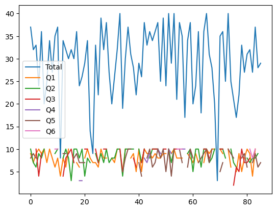

```python
a.plot()
plt.show()
```

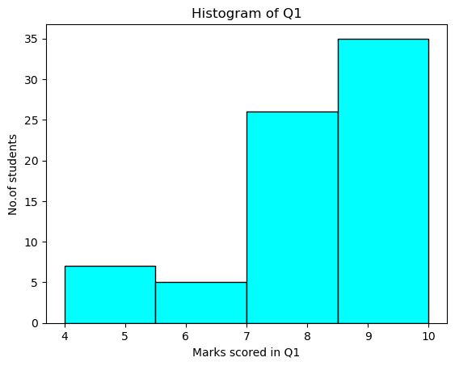

```python
plt.hist(a['Q1'],color='cyan',edgecolor='black',bins=4)
plt.xlabel("Marks scored in Q1")
plt.ylabel("No.of students")
plt.title("Histogram of Q1")
```

# The code creates a histogram to visualize the distribution of marks scored in Q1, with labeled axes, a title, cyan bars, and black edges, using 4 bins

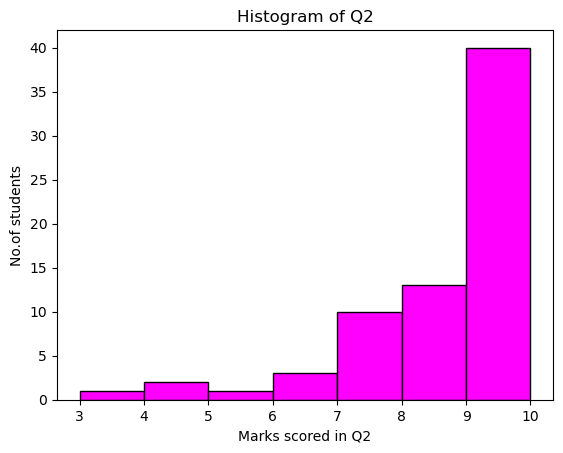

```python
plt.hist(a["Q2"],color='magenta',bins=7,edgecolor='black')
plt.xlabel("Marks scored in Q2")
plt.ylabel("No.of students")
plt.title("Histogram of Q2")
```

# a histogram to display the distribution of marks scored in Q2, using 7 bins, magenta bars with black edges, and labeled axes with a descriptive title.

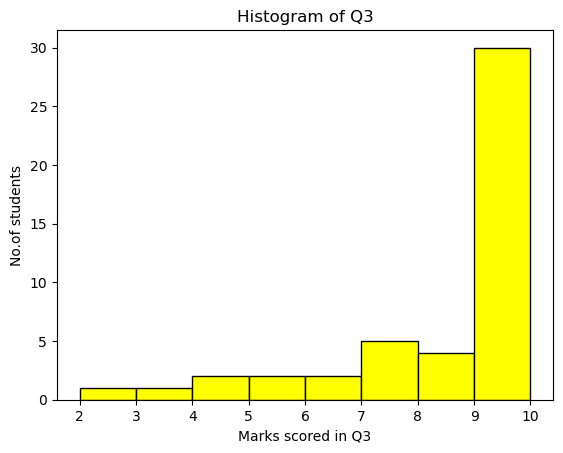

```python
plt.hist(a["Q3"],color='yellow',bins=8,edgecolor='black')
plt.xlabel("Marks scored in Q3")
plt.ylabel("No.of students")
plt.title("Histogram of Q3")
```

# histogram to represent the distribution of marks scored in Q3, using 8 bins, yellow bars with black edges, and labeled axes with a title.

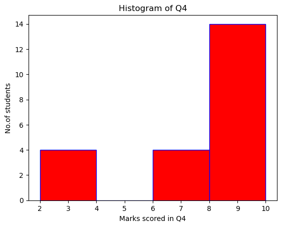

```python
plt.hist(a["Q4"],color='red',bins=4,edgecolor='blue')
plt.xlabel("Marks scored in Q4")
plt.ylabel("No.of students")
plt.title("Histogram of Q4")
```

# histogram to visualize the distribution of marks scored in Q4, using 4 bins, red bars with blue edges, and labeled axes along with a title.

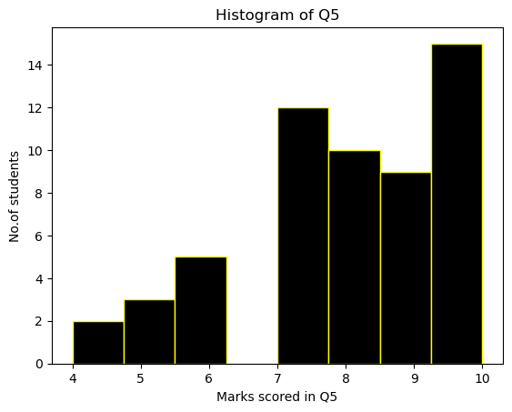

```python
plt.hist(a["Q5"],color='black',bins=8,edgecolor='yellow')
plt.xlabel("Marks scored in Q5")
plt.ylabel("No.of students")
plt.title("Histogram of Q5")
```

# histogram to display the distribution of marks scored in Q5, using 8 bins, black bars with yellow edges, and labeled axes along with a title.

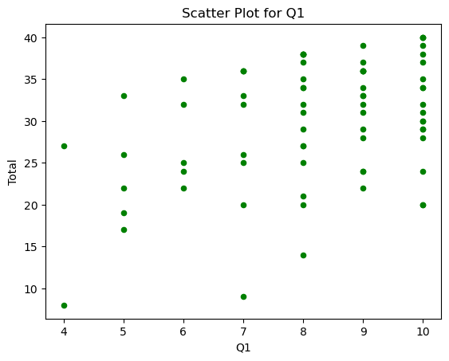

```python
a.plot.scatter(x = 'Q1', y = 'Total',color='green',s=20)
plt.title("Scatter Plot for Q1")
```

# scatter plot showing the relationship between the scores in "Q1" (x-axis) and the "Total" scores (y-axis), with green markers of size 20 and a title "Scatter Plot for Q1".

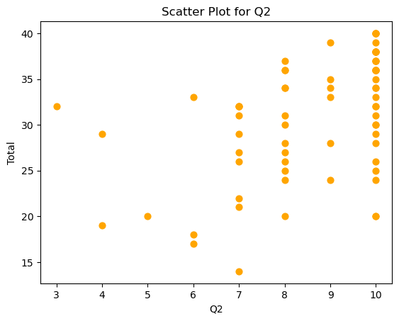

```python
a.plot.scatter(x = 'Q2', y = 'Total',color='orange',s=40)
plt.title("Scatter Plot for Q2")
```

# scatter plot to visualize the relationship between scores in "Q2" (x-axis) and "Total" scores (y-axis), with orange markers of size 40 and the title "Scatter Plot for Q2".

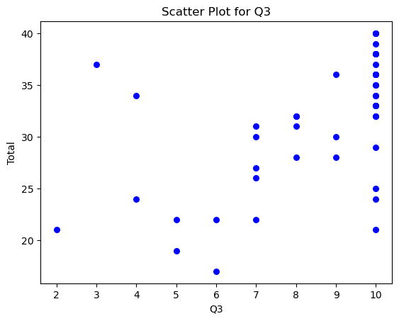

```python
a.plot.scatter(x = 'Q3', y = 'Total',color='blue',s=30)
plt.title("Scatter Plot for Q3")
```

# scatter plot to display the relationship between scores in "Q3" (x-axis) and "Total" scores (y-axis), using blue markers of size 30 and the title "Scatter Plot for Q3".

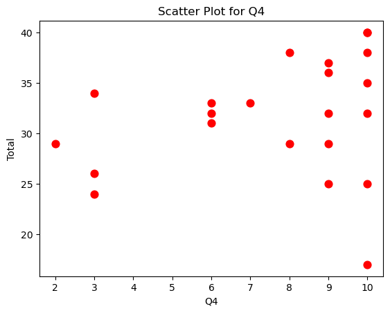

```python
a.plot.scatter(x = 'Q4', y = 'Total',color='red',s=60)
plt.title("Scatter Plot for Q4")
```

# scatter plot to show the relationship between scores in "Q4" (x-axis) and "Total" scores (y-axis), using red markers of size 60 and the title "Scatter Plot for Q4".

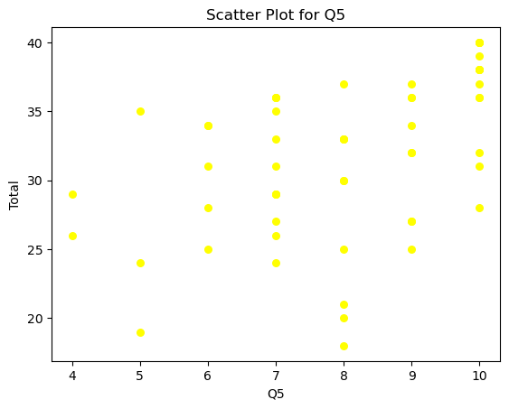

```python
a.plot.scatter(x = 'Q5', y = 'Total',color='yellow',s=30)
plt.title("Scatter Plot for Q5")
```

# scatter plot to visualize the relationship between scores in "Q5" (x-axis) and "Total" scores (y-axis), with yellow markers of size 30 and the title "Scatter Plot for Q5".

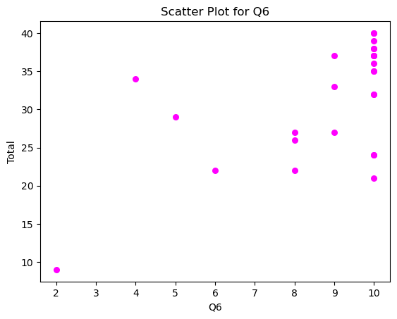

```python
a.plot.scatter(x = 'Q6', y = 'Total',color='magenta',s=30)
plt.title("Scatter Plot for Q6")
```

# scatter plot to illustrate the relationship between scores in "Q6" (x-axis) and "Total" scores (y-axis), using magenta markers of size 30 and the title "Scatter Plot for Q6".

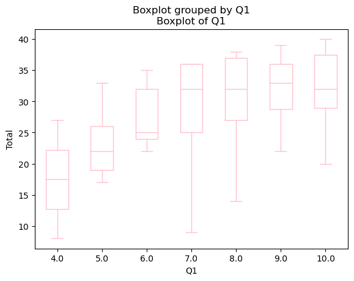

```python
a.boxplot(by='Q1', column =['Total'], grid = False,color='pink')
plt.title("Boxplot of Q1")
plt.ylabel("Total")
plt.show()
```

# boxplot to display the distribution of "Total" scores based on the categories in "Q1", with pink coloring, no grid lines, and the title "Boxplot of Q1". The y-axis is labeled as "Total".

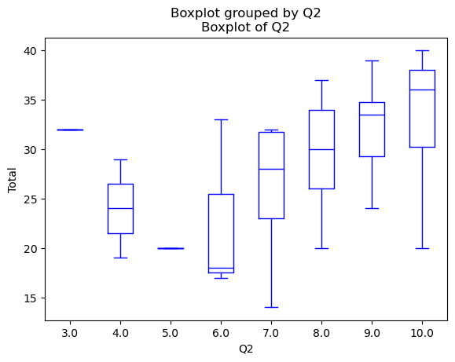

```python
a.boxplot(by='Q2', column =['Total'], grid = False,color='blue')
plt.title("Boxplot of Q2")
plt.ylabel("Total")
plt.show()
```

# boxplot to visualize the distribution of "Total" scores based on the categories in "Q2", with blue coloring, no grid lines, and the title "Boxplot of Q2". The y-axis is labeled as "Total".

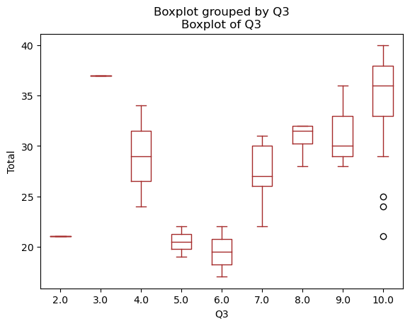

```python
a.boxplot(by='Q3', column =['Total'], grid = False,color='brown')
plt.title("Boxplot of Q3")
plt.ylabel("Total")
plt.show()
```

# boxplot to show the distribution of "Total" scores based on the categories in "Q3", with brown coloring, no grid lines, and the title "Boxplot of Q3". The y-axis is labeled as "Total".

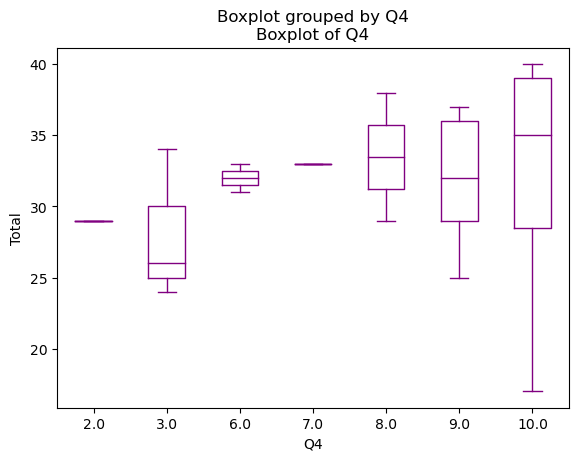

```python
a.boxplot(by='Q4', column =['Total'], grid = False,color='purple')
plt.title("Boxplot of Q4")
plt.ylabel("Total")
plt.show()
```